# Part I - (Dataset Exploration Title)

## Distribution of time people spent in ridding bike

Female participants used the bike for long time than male, while the time of trip were approximately equaly in both categories.

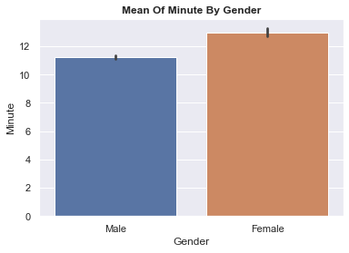

## Distribution of the user type by gender

As the majority were male, the distribution were user types were different totaly different in gender, as the majority of the user were subscriber.

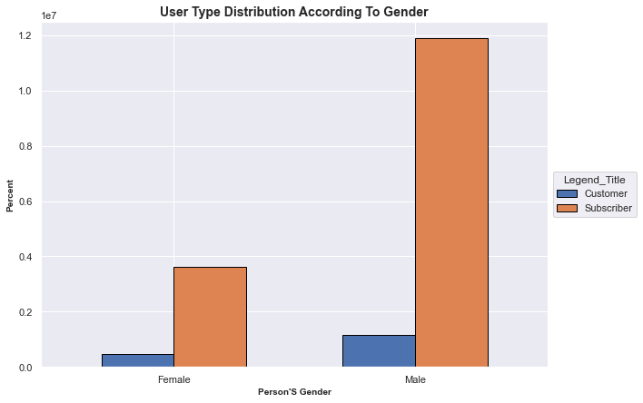

## Time distribution by Gender classification in user type

In majority, female spent a lot of time on bike then male as more of them were customer.

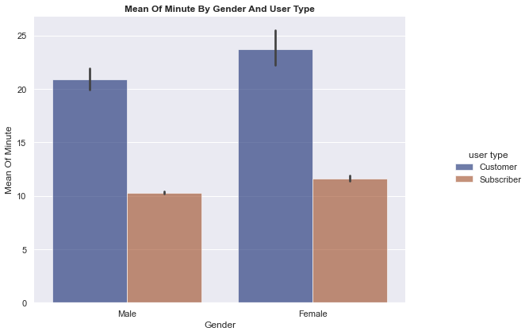

## The difference of people in gender on the days of the week.

It was still indicated that female were young compared to male, as also female were fewer in ridding bike in all days of the week.

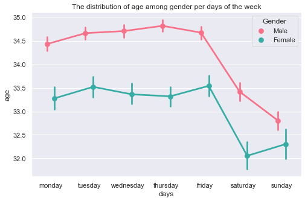

## Key Insights for Presentation

The interested factor was to identify the gender distribution and effect on other factors, as gender distribution were significant different in all user case.